# Exercicios

João Paulo Pereira

### Carregando dependencias

```r
library(readxl)
library(tidyverse)
library(lubridate)
library(janitor)
library(ggplot2)
library(forecast)
library(fpp2)
library(seasonal)
library(dplyr)
```

# Parte 1

```r
load(file='us_change.rda')
data <- us_change %>%  janitor::clean_names()
head(data)
```

| quarter | consumption | income | production | savings | unemployment |
| --- | --- | --- | --- | --- | --- |
| 1970-01-01 | 0.6185664 | 1.0448013 | -2.4524855 | 5.299014 | 0.9 |
| 1970-04-01 | 0.4519840 | 1.2256472 | -0.5514595 | 7.789894 | 0.5 |
| 1970-07-01 | 0.8728718 | 1.5851538 | -0.3586518 | 7.403984 | 0.5 |
| 1970-10-01 | -0.2718479 | -0.2395449 | -2.1856909 | 1.169898 | 0.7 |
| 1971-01-01 | 1.9013450 | 1.9759249 | 1.9097644 | 3.535667 | -0.1 |
| 1971-04-01 | 0.9148773 | 1.4459085 | 0.9015695 | 5.874764 | -0.1 |

### a) Construa um novo tibble no qual todas as variáveis sejam disponibilizadas em número índice, assumindo valor 100 no primeiro trimestre do ano 2000 (ie 2010Q1 = 100).

```r
#data <- us_change %>% janitor::clean_names()

# income_2000q1 <- data$income[121]
#production_2000q1 <- data$production[121]
# consumption_2000q1 <- data$consumption[121]
# savings_2000_q1 <- data$savings[121]
# uenployment_2000_q1 <- data$unemployment[121]


#index_100 <- data %>% mutate(index_income = income / income_2000q1 * 100) %>%
#                 mutate(index_production = production / production_2000q1 * 100) %>%
#                 mutate(index_consumption = consumption / consumption_2000q1 * 100) %>%
#                 mutate(index_savings = savings / savings_2000_q1 * 100) %>%
#                 mutate(index_unemployment = (unemployment / unenployment_2000_q1) * 100) %>%
#                 select(quarter, index_income, index_consumption, index_savings,index_unemployment, index_production)
index_100 <- data %>% filter(quarter >= "2000-01-01")

index_100$consumption[1] <- 100
index_100$production[1] <- 100
index_100$income[1] <- 100
index_100$savings[1] <- 100
index_100$unemployment[1] <- 100

for (i in 2:length(index_100$quarter)) {
  index_100$consumption[i] <- (1 + index_100$consumption[i]/100) * index_100$consumption[i-1];
  index_100$production[i] <- (1 + index_100$production[i]/100) * index_100$production[i-1];
  index_100$income[i] <- (1 + index_100$income[i]/100) * index_100$income[i-1];
  index_100$savings[i] <- (1 + index_100$savings[i]/100) * index_100$savings[i-1];
  index_100$unemployment[i] <- (1 + index_100$unemployment[i]/100) * index_100$unemployment[i-1];
}

head(index_100)
```

| quarter | consumption | income | production | savings | unemployment |
| --- | --- | --- | --- | --- | --- |
| 2000-01-01 | 100.0000 | 100.0000 | 100.00000 | 100.00000 | 100.0000 |
| 2000-04-01 | 100.9612 | 101.0998 | 101.20298 | 102.60179 | 100.0000 |
| 2000-07-01 | 101.9478 | 102.2670 | 101.10461 | 104.71393 | 99.9000 |
| 2000-10-01 | 102.8209 | 102.6319 | 100.89133 | 94.21382 | 99.9000 |
| 2001-01-01 | 103.2316 | 103.5578 | 99.55156 | 106.33893 | 100.2996 |
| 2001-04-01 | 103.4754 | 103.3767 | 98.28748 | 98.75558 | 100.5002 |

### b) Explore a correlação entre as variáveis. Qual a diferença entre se calcular acorrelação das variáveis em número índice e em taxa de variação?

- Correlação sem indice

```r
correl <- cor(data %>% select(-"quarter")) %>% round(2)
correl
```

```
##              consumption income production savings unemployment
## consumption         1.00   0.38       0.53   -0.26        -0.53
## income              0.38   1.00       0.27    0.72        -0.22
## production          0.53   0.27       1.00   -0.06        -0.77
## savings            -0.26   0.72      -0.06    1.00         0.11
## unemployment       -0.53  -0.22      -0.77    0.11         1.00
```

- Correlação sem indice(pós 2000)

```r
correl_pos_2000 <- cor(data %>% filter(quarter >= "2000-01-01")  %>% select(-"quarter")) %>% round(2)
correl_pos_2000
```

```
##              consumption income production savings unemployment
## consumption         1.00   0.23       0.48   -0.24        -0.48
## income              0.23   1.00       0.14    0.85        -0.09
## production          0.48   0.14       1.00   -0.06        -0.73
## savings            -0.24   0.85      -0.06    1.00         0.11
## unemployment       -0.48  -0.09      -0.73    0.11         1.00
```

- Correlação com indice

```r
correl_indice <- cor(index_100 %>% select(-"quarter")) %>% round(2)
correl_indice
```

```
##              consumption income production savings unemployment
## consumption         1.00   1.00       0.76    0.08        -0.12
## income              1.00   1.00       0.73    0.17        -0.08
## production          0.76   0.73       1.00   -0.13        -0.55
## savings             0.08   0.17      -0.13    1.00         0.17
## unemployment       -0.12  -0.08      -0.55    0.17         1.00
```

## C) Construa gráficos que contribuam em seu entendimento sobre a dinâmicade cada variável do dataset, bem como as relações entre elas. Assim, porexemplo, como ponto de partida plote gráficos de dispersão conjunta dasvariáveis, bem como suas evoluções ao longo do tempo. Sinta-se livre paracomplementar tal caracterização com todo e qualquer arsenal analítico quejulgue interessante.

- Correlação

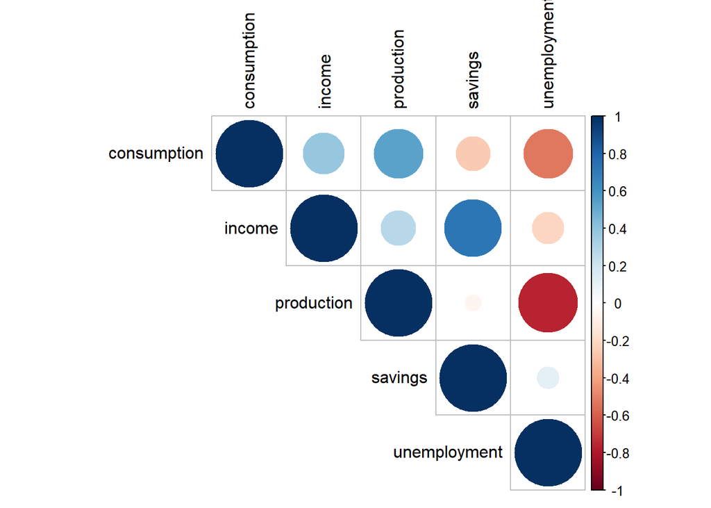

```r
corrplot::corrplot(correl,type = "upper", tl.col="black")
```

- Correlação pós 2000

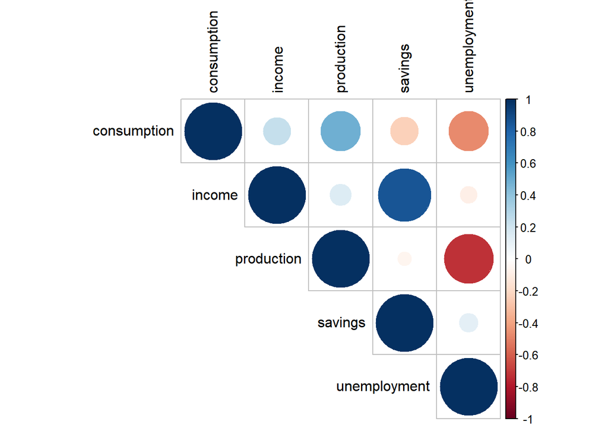

```r
corrplot::corrplot(correl_pos_2000,type = "upper", tl.col="black")
```

- Correlação pós 2000(número indice)

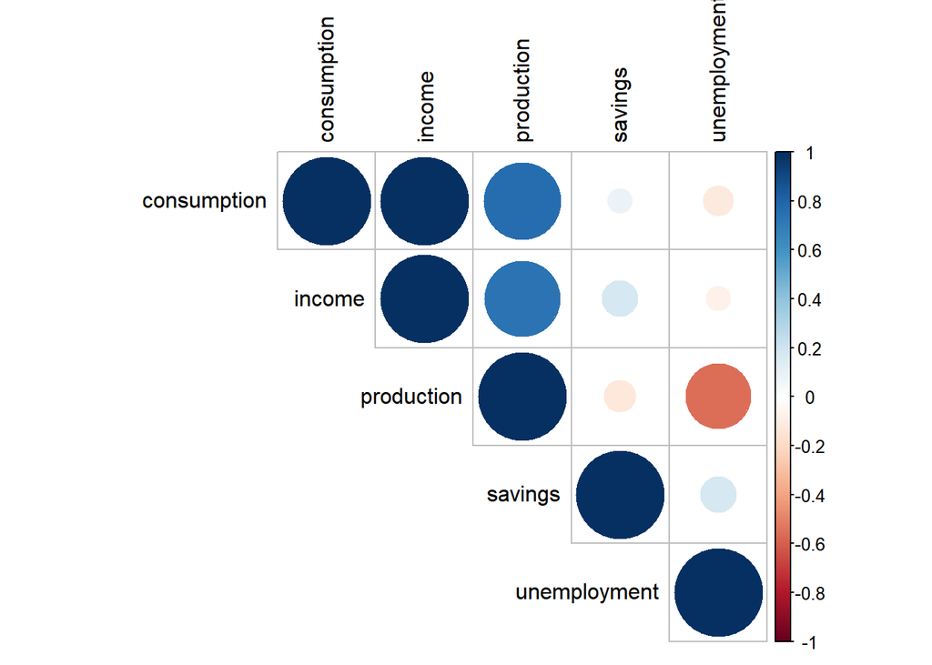

```r
corrplot::corrplot(correl_indice,type = "upper", tl.col="black")
```

- Grafico de evolução da Produção e Consumo(utilizando as variaveis originais)

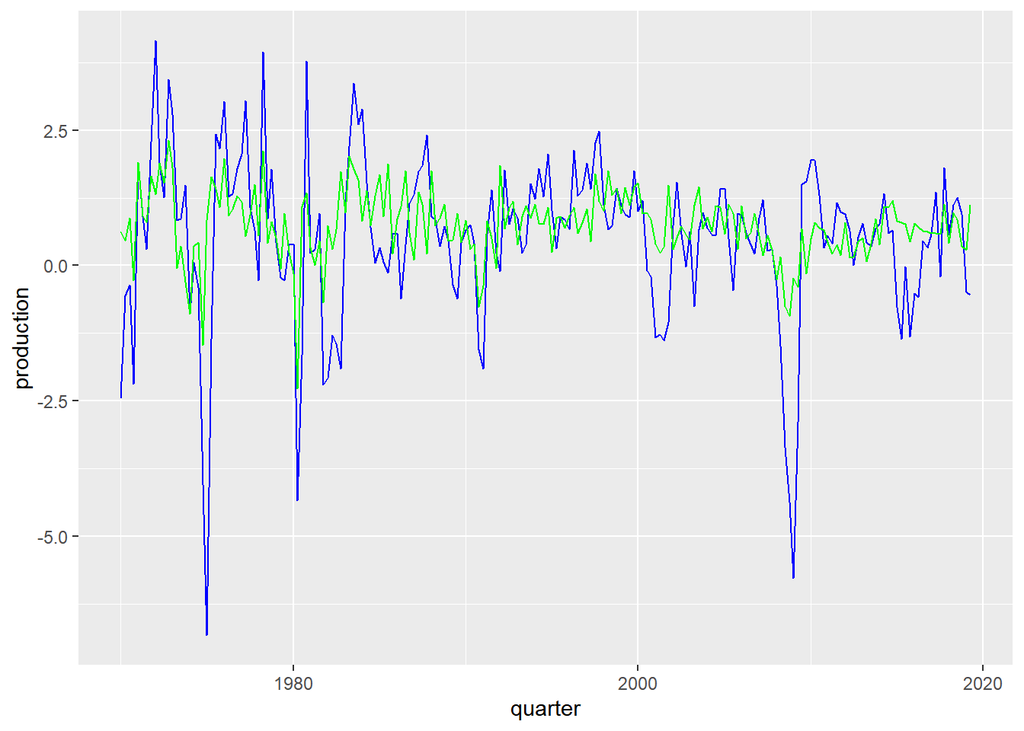

```r
data  %>%
  ggplot( aes(x = quarter) ) +
  geom_line(aes(y = production), color = "blue") +
  geom_line(aes(y = consumption), color = "green")
```

- Gráfico de evolução da Renda e do Consumo(utilizando as variaveis originais)

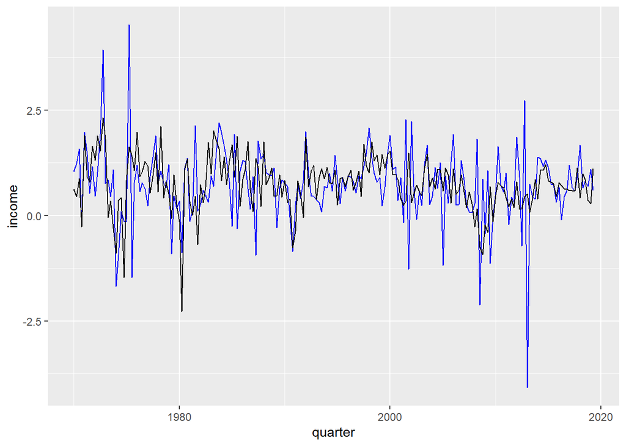

```r
data %>%
  ggplot( aes(x = quarter) ) +
  geom_line(aes(y = income), color = "blue") +
  geom_line(aes(y = consumption), color = "black")
```

### d) A partir das visualizações obtidas no item anterior, que tipo de aprendizadovocê consegue extrair acerca de (i) evolução das variáveis ao longo do tempoe (ii) das correlações nas dinâmicas das diversas variáveis?

Maior desemprego = menor consumo. Menor desemprego = Maior Renda = Maior Consumo. Maior renda = Maior Poupança. Maior produção = menor desemprego

### e) Você consegue identificar, visualmente, alguns movimentos bruscos/atípicos/anômalosna evolução das séries? Tente destacar tais pontos nos gráficos construídos2:

Dá para notar os efeitos do 11 de setembro e da crise de 2008. além disso da para notar que apartir de meados da década de 80 a um “desprendimento” das linhas de Consumo e Produção. só com esse dataset não da para concluir o que houve, mas imagino que tenha alguma relação com a migração de produção para paises onde o custo é mais baixo.

# Parte 2 - Séries de tempo, ciclo, sazonalidade e tendência

## O arquivo “retail.xlsx” contém informações sobre vendas mensais de varejo para diversos estados da Austrália.

### A) Leia os dados contidos no arquivo “retail.xlsx”. Qual cuidado adicional você precisou ter ao realizar essa importação?

```r
retail = readxl::read_excel("./retail.xlsx", skip = 1)
retail = janitor::clean_names(retail)
View(retail)
```

Utilizei a função read_excel do pacote readxl, tive que pular a primeira linha.

### B) Selecione uma das variáveis e as converta para o formato “time series”.

```r
#retail$series_id <- ymd(retail$series_id)

retail_time_series <- ts(retail$a3349335t, start = c(1982, 1), frequency = 12)
```

### C) Explore a série escolhida por meio da construção de gráﬁcos. Emparticular, se estiver utilizando o R,teste as funções ggseasonplot e ggmonthplot. O que você consegue identiﬁcar em termos de ciclo, sazonalidade e tendência?

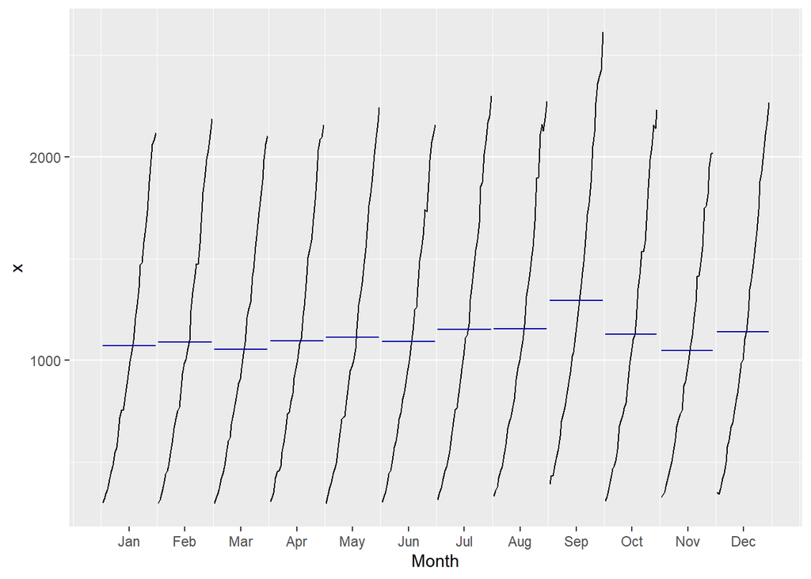

```r
ggmonthplot(retail_time_series)
```

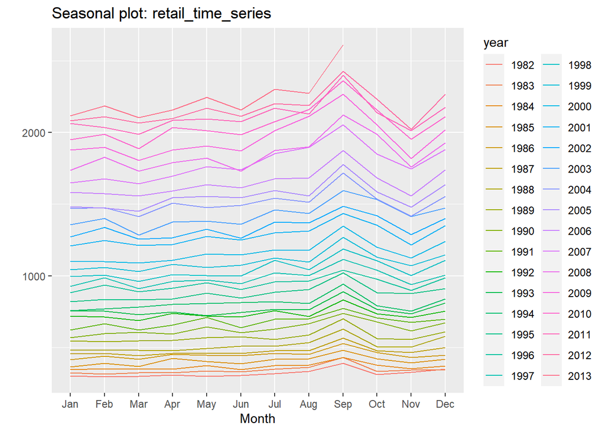

```r
ggseasonplot(retail_time_series)
```

Utilizando o ggmonthplot e o ggseasonplot, é possivel notar que a tendencia é de incremento das vendas ao longo dos anos, e que há uma sazonalidade entre os meses de setembro(alta) seguidos por uma baixa em outubro e novembro. utilizando esses gráficos não consegui visualizar um ciclo.

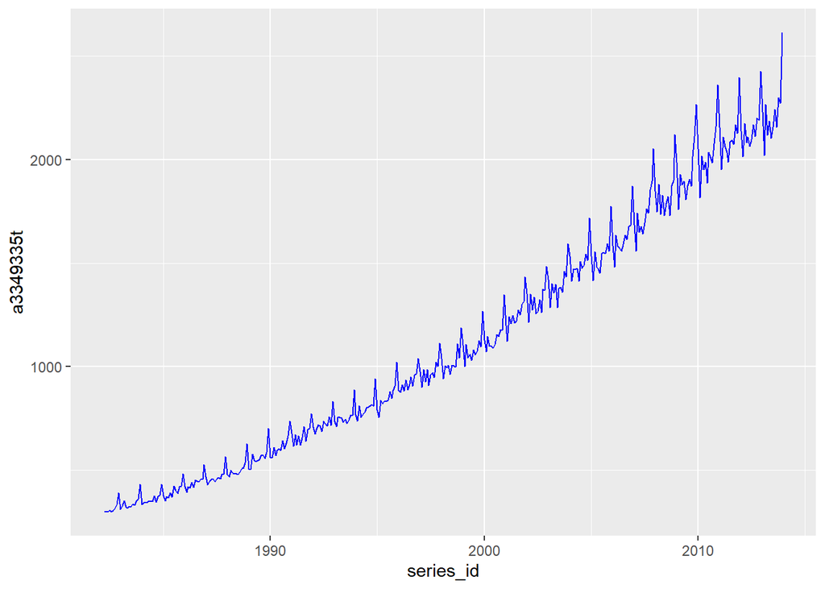

```r
retail %>%
  ggplot( aes(x = series_id) ) +
  geom_line(aes(y = a3349335t), color = "blue")
```

Gerando um grafico de linha é possivel notar o ciclo de ocilações de subida e de queda na série de forma repetida.

### D) Decomponha a série utilizando o método X11. Ele revela algum outlier ou padrões anômalos não identiﬁcados anteriormente?

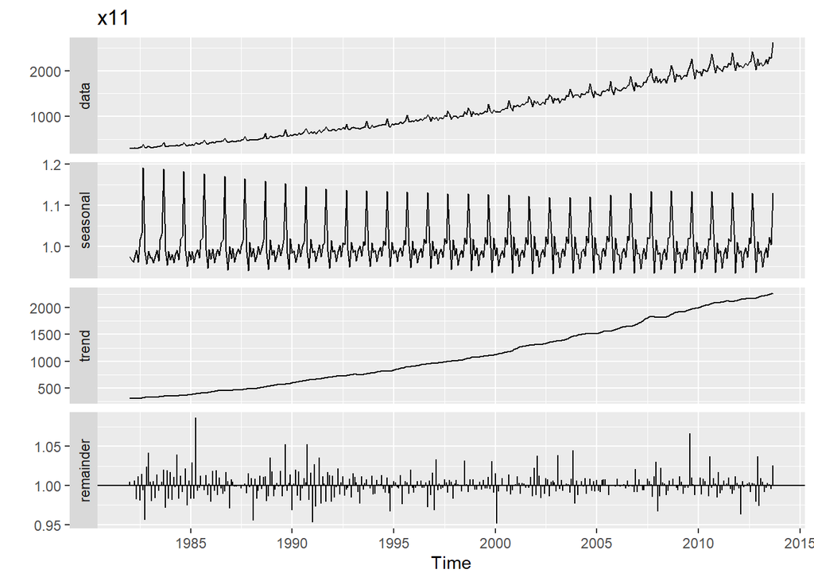

```r
x11 <- retail_time_series %>% seas(x11 = "")
autoplot(x11) +
  ggtitle("x11")
```

Deu para notar uma ocilação no ano de 2008.

# Parte 2

## 3. Dataset Spotify - package “spotifyr”

```r
spotify_songs <- readr::read_csv('https://raw.githubusercontent.com/rfordatascience/tidytuesday/master/data/2020/2020-01-21/spotify_songs.csv')
group_genre <- spotify_songs %>% group_by(playlist_genre) %>% summarise(total = sum(track_popularity, na.rm=TRUE)) %>% ungroup()
```

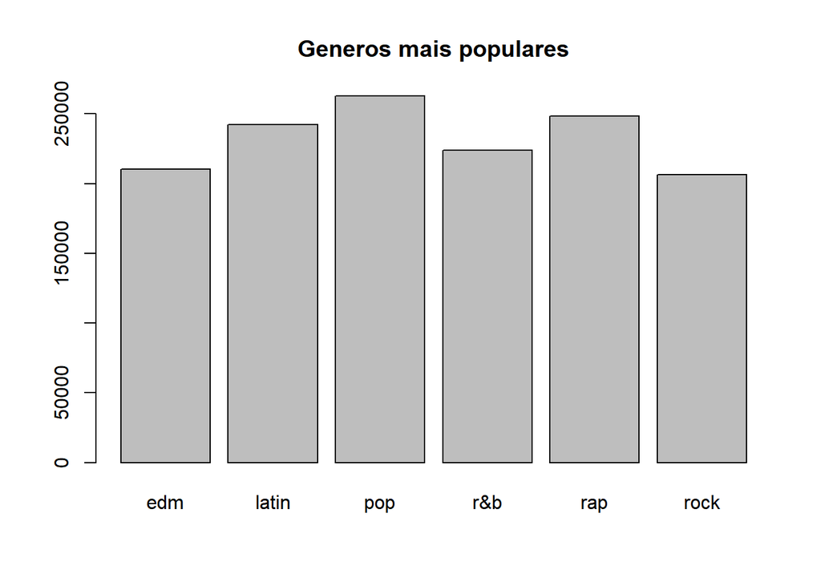

```r
barplot(group_genre$total, names.arg = group_genre$playlist_genre, main="Generos mais populares")
```

## 4. Video Games Dataset

```r
video_games <- readr::read_csv("https://raw.githubusercontent.com/rfordatascience/tidytuesday/master/data/2019/2019-07-30/video_games.csv")
group_dev <- video_games %>%
              group_by(developer) %>%
              summarise(total = n()) %>%
              ungroup()
group_dev <- group_dev %>% drop_na()
group_dev <- group_dev %>% arrange(desc(group_dev$total))
group_dev <- group_dev[1:10,]

head(group_dev)
```

| developer | total |
| --- | --- |
| Choice of Games | 92 |
| KOEI TECMO GAMES CO., LTD. | 70 |
| Ripknot Systems | 62 |
| SEGA | 60 |
| Laush Dmitriy Sergeevich | 50 |
| Nikita "Ghost_RUS" | 48 |

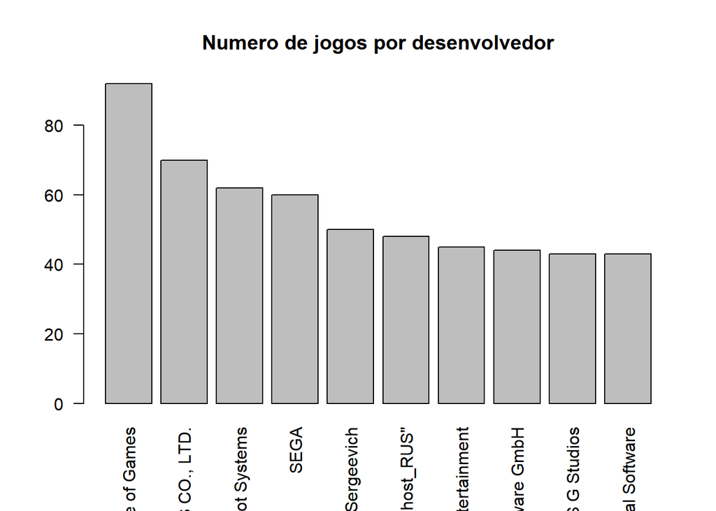

```r
barplot(group_dev$total, names.arg = group_dev$developer, main="Numero de jogos por desenvolvedor", las=2)
```